# UDACITY R Data Analysis Lesson 9

Trenton J. McKinney

Resources:

1. https://www.rdocumentation.org/packages/rmarkdown/versions/1.8/topics/html_notebook
2. http://rmarkdown.rstudio.com/html_document_format.html
3. https://bootswatch.com/

```r
library(readxl)
library(tibble)
library(ggplot2)
library(dplyr)
library(scales)
library(memisc)
library(reshape2)
library(lubridate)
library(ggthemes)
library(gridExtra)
library(alr3)
library(rio)
library(GGally)
library(RColorBrewer)
```

### Lesson 9: Setup & General

```r
data("diamonds")
```

### Lesson 9.2: Linear Regression Models

In this lesson, Solomon will be using a linear regression model to predict diamond price using other variables in the diamonds dataset. If you are not familiar with linear regression, you may want to take a break and go through [Lesson 15 of Udacity’s Intro to Inferential Statistics](https://classroom.udacity.com/courses/ud201) course, which covers linear regression. When you’re done, you’ll be ready to come back and apply your new knowledge to the diamonds dataset!

### Lesson 9.3: Scatterplot Review

Let’s run our usual code to load in the data side. For review, let’s have you create a scatter plot in the next exercise.

We’ve seen this kind of code before. All we’re doing is we’re using qplot to plot the price of diamond against its carat weight. And we’re going to trim the top percentile off of both carat and price. If you use the full ggplot syntax, your code will look something like this.

Hint: Use the `quantile()` function inside of `xlim` and `ylim` to omit the top 1% of values for each variable.

Let’s start by examining two variables in the data set. The scatterplot is a powerful tool to help you understand the relationship between two continuous variables.

We can quickly see if the relationship is linear or not. In this case, we can use a variety of diamond characteristics to help us figure out whether the price advertised for any given diamond is reasonable or a rip-off.

Let’s consider the price of a diamond and it’s carat weight. Create a scatterplot of price (y) vs carat weight (x).

Limit the x-axis and y-axis to omit the top 1% of values.

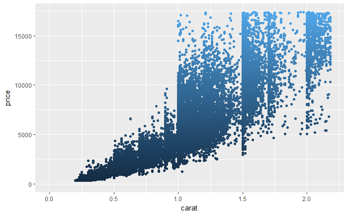

```r
ggplot(data = diamonds, aes(x = carat, y = price)) +
  geom_point(aes(color = price), show.legend = FALSE) +
  xlim(0, quantile(diamonds$carat, 0.99)) +
  ylim(0, quantile(diamonds$price, 0.99))
```

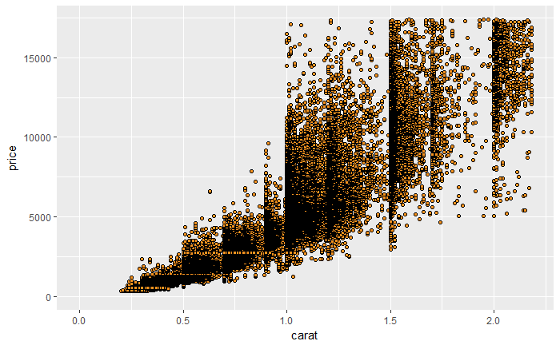

```r
ggplot(diamonds, aes(x = carat, y = price)) +
  scale_x_continuous(lim = c(0, quantile(diamonds$carat, 0.99))) +
  scale_y_continuous(lim = c(0, quantile(diamonds$price, 0.99))) +
  geom_point(fill = I('#F79420'), color = I('black'), shape = 21)
```

### Lesson 9.4: Price and Carat Relationship

Alright, so let me ask you this question. What do you notice about the relationship here between price and carat? Go ahead and enter your response here.

When we look at the plot, a few things pop out right away. We can see a nonlinear relationship. Maybe it’s exponential or maybe it’s something else. We can see that the dispersion or variance of the relationship also increases as carat size increases. With just a quick look at the data we’ve learned two important things about the functional relationship between price and carat size. We can add a linear trim line to the plot by using the stat smooth function with method equals lm. We can see that the linear trend line doesn’t go through the center of the data at some key places. It misses it here. It should curve a little bit in the center of the relationship, and it should slope up more toward the end. And if we tried to use this to make predictions, we might be off for some key places inside and outside of the existing data that we have displayed.

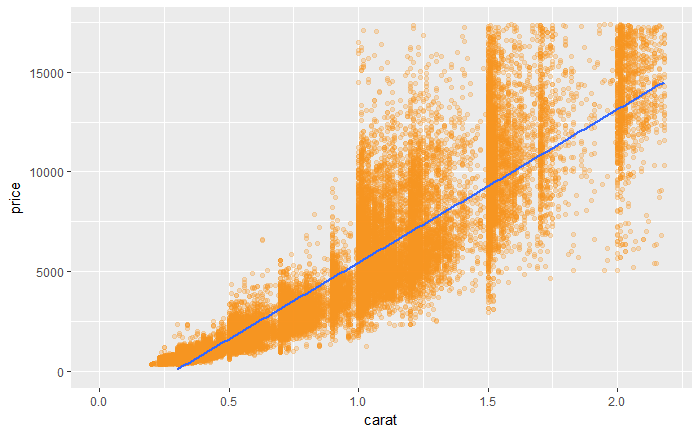

```r
ggplot(diamonds, aes(x = carat, y = price)) +
  geom_point(color = I('#F79420'), alpha = 1/4) +
  stat_smooth(method = 'lm') +
  scale_x_continuous(lim = c(0, quantile(diamonds$carat, 0.99))) +
  scale_y_continuous(lim = c(0, quantile(diamonds$price, 0.99)))
```

### Lesson 9.5: Frances Gerety

- [Have You Ever Tried to Sell a Diamond?](https://www.theatlantic.com/magazine/archive/1982/02/have-you-ever-tried-to-sell-a-diamond/304575/)
- [De_Beers: Diamond_monopoly](https://en.wikipedia.org/wiki/De_Beers#Diamond_monopoly)

A diamond is forever. This tag along has appeared in every De Beers ad since 1948. In 1999, two weeks before Mrs. Gerety died, Advertising Age named it the slogan of the century.

### Lesson 9.6: The Rise of Diamonds

Many argue that this campaign gave birth to modern demand advertising. The objective here was not demand generation nor branch strengthening. But simply to impress the glamor, the sentiment and the emotional charge contained in the product, itself. The company gave diamonds to movie stars. They sent out press packets emphasizing the size of diamonds that celebrities gave each other. They loaned diamonds to prominent socialites attending events like the Kentucky Derby or the Academy Awards. And even persuaded the British royal family to wear diamonds over other gems. Later, De Beers sought to market diamond rings to couples as a status symbol. To reflect quote, a man’s success in life. A 1980’s add introduced the famous two month bench mark. Isn’t two months salary a small price to pay for something that lasts forever? By any reasonable measure, Francis Geary succeeded. Getting engaged in America means getting a diamond ring. Can you think of a movie where two people get engaged with out a diamond? When you get engaged on Facebook, what icon does the site display? Still think this might not be the most successful mass persuasion effort in history? I present to you a James Bond film. Whose title bears the diamond cartel’s trademark. Awe-inspiring and a little terrifying. Let’s open the data set.

[The Counte of Monte Cristo](https://www.youtube.com/watch?v=PJyRNeCErNE) and [Knocked Up](https://www.youtube.com/watch?v=Be3sZKmfb9g) are two movies that have proposals without engagement rings.

These are the only two movies that came to mind…after A LOT of time. Can you think of any others? If so, share it in the discussions!

### Lesson 9.7: ggpairs Function

We can see what might be relationships between price and clarity and price and color, which we’ll keep in mind for later when start modelling our data. You might remember this when you create the box plots in problem set three. Be that as it may, the critical factor driving price is the size, or the carat weight of the diamond. As we saw at the start of the lesson, the relationship between price and diamond size is nonlinear. What might explain this pattern? On the supply side, larger continuous chunks of diamonds without significant flaws are probably harder to find than smaller ones. This might help explain the sort of exponential looking curve, and I thought I noticed this when I was shopping for a diamond for my soon to be wife. Of course, this is related to the fact that the weight of a diamond is a function of volume, and volume is a function of the length times the width times the height of a diamond, and this suggests that we might be especially interested in the cube root of carat weight. It’s often the case, that leveraging substantive knowledge about your data like this can lead to especially fruitful transformations, and we’ll see that in a second.

The “params” argument to the `ggpairs` function are there to change the shape of the plotted points in the plot matrix, to make them easier to see. GGally 1.0 changes the syntax of these plotting parameters to no longer be part of a params argument, and instead can be specified as follows:

`ggpairs(diamond_samp, lower = list(continuous = wrap("points", shape = I('.'))), upper = list(combo = wrap("box", outlier.shape = I('.'))))`

You can click on the packages tab in RStudio to determine which packages have been installed.

You may receive a message when installing the new packages. If so, click cancel, clear your workspace, and try installing the packages again.

In this video, Solomon works with the `plyr` package. We worked with the `dplyr` package to manipulate data frames and to create new ones throughout the course. dplyr is the latest version of `plyr` that is specifically for working with data frames.

Similarly, we worked with the `reshape2` package, which is the newest version of the `reshape` package.

[ggpairs output](https://s3.amazonaws.com/udacity-hosted-downloads/ud651/ggpairs_landscape.pdf) When you duplicate the plot matrix on your local machine, you may want to add a `axisLabels = 'internal'` argument to your `ggpairs` function call to have the variable names on the diagonal of the matrix rather than on the outside.

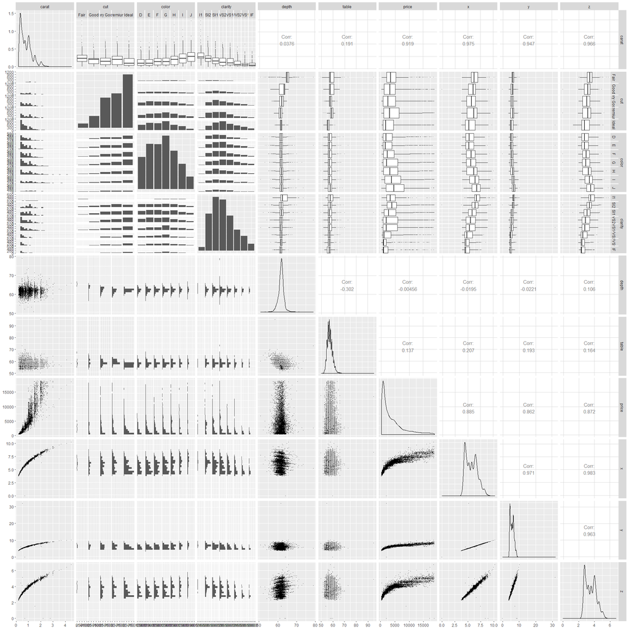

```r
set.seed(20022012)
diamond_samp <- diamonds[sample(1:length(diamonds$price), 10000), ]
ggpairs(diamond_samp,
  lower = list(continuous = wrap("points", shape = I('.'))),
  upper = list(combo = wrap("box", outlier.shape = I('.'))))
```

### Lesson 9.8: The Demand of Diamonds

On the demand side, customers in the market for a less expensive, smaller diamond are probably more sensitive to price than more well-to-do buyers. Many less than one carat customers would surely never buy a diamond. Diamond were not for the social norm of presenting one when proposing. And there are fewer customers who can afford a bigger diamond that is one that is larger than than one carat, hence we shouldn’t expect the market for bigger diamonds to be as competitive as the one for smaller diamonds. So it makes sense that the variants As well as the price would increase with carat size. Now often the distribution of any monetary variable like dollars will be highly skewed and vary over orders of magnitude. Now this can result from path dependence for example the rich getting richer, or multiplicative processes like year on year inflation, or some combination of both. Hence it’s a good idea to look into compressing any such variable by putting it on a log scale. For more tips on when to use the log scale and how to transform your variables check out the link in the instructor notes. Let’s examine the distribution of price again. In this next programming exercise you complete the code to generate two price histograms.

Here we’re just using Q plot to produce two histograms of price. One on just a regular scale and one on the log ten scale. We’re to use this grid extra library to plot both plots in the same window and here’s what the result looks like.

[Log Transformations for Skewed and Wide Distributions](https://www.r-statistics.com/2013/05/log-transformations-for-skewed-and-wide-distributions-from-practical-data-science-with-r/)

Create two histograms of the price variable and place them side by side on one output image.

We’ve put some code below to get you started.

The first plot should be a histogram of price and the second plot should transform the price variable using log10.

Set appropriate bin widths for each plot. ggtitle() will add a title to each histogram.

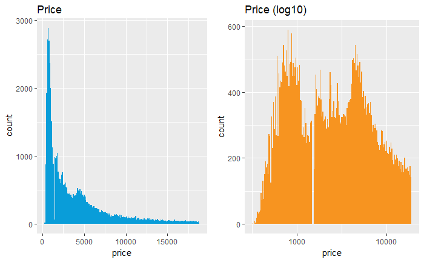

```r
p_plot <- ggplot(diamonds, aes(x = price))
p1 = p_plot +
  geom_histogram(binwidth = 100, aes(fill = I('#099DD9'))) +
  ggtitle('Price')
p2 = p_plot +
  geom_histogram(binwidth = 0.01, aes(fill = I('#F79420'))) +
  ggtitle('Price (log10)') +
  scale_x_log10()
grid.arrange(p1, p2, ncol = 2)
```

### Lesson 9.9: Connecting Demand and Price Distribution

When looking at these plots, what do you notice? Think specifically about the two peaks in the transformed plot and how they relate to the demand for diamonds. Alright let me know what you think here.

Indeed we can see that the prices for diamonds are pretty heavily skewed, but when you put those prices on a log ten scale, they seem much better behaved. They’re much closer to the bell curve of a normal distribution. We can even see a little bit of evidence of bimodality on this log ten scale. Which is consistent with our two class rich buyer poor buyer speculation about the nature of customers for diamonds. You actually saw a sneak peek of this in problem set set three when you looked at the log ten of price by cut.

### Lesson 9.10: Scatterplot Transformation

Now that we have a better understanding of our variables, and the overall demand for diamonds, let’s replot the data. This time we’ll put price on a log10 scale, and here’s what it looks like. This plot looks better than before. On the log scale, the prices look less dispersed at the high end of Carat size and price, but actually we can do better. Let’s try using the cube root of Carat in light of our speculation about flaws being exponentially more likely in diamonds with more volume. Remember, volume is on a cubic scale. First, we need a function to transform the Carat variable. If you’d like to learn more about writing your own functions in R, check out the links in the instructor notes. This may seem like a lot of code, but really, there’s only one new piece here. It’s this cube root trans-function. It’s a function that takes the cube root of any input variable, and it also has an inverse function to undo that operation, which we need to display the plot correctly. Then when we get to our actual ggplot command. What we’ll do is we’ll use the scale_x_continuous argument to transform the x axis with this cube root transformation function. Keep in mind we’re also transforming the y axis with this log10 transformation that we discussed previously. And, let’s see what this plot looks like. Taking a look at the plot, we can actually see that with these transformations that we used to get our data on this nice scale. Things look almost linear. We can now move forward and see about modelling our data using just a linear model.

[Basic Structure of a Function](https://www.youtube.com/watch?v=Z1wB1rHAYzQ&list=PLOU2XLYxmsIK9qQfztXeybpHvru-TrqAP)

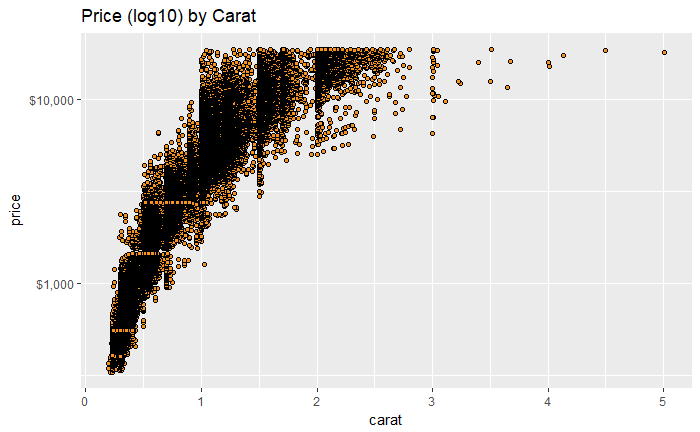

```r
ggplot(diamonds, aes(x = carat, y = price)) +
  geom_point(fill = I('#F79420'), color = I('black'), shape = 21) +
  scale_y_log10(labels = dollar) +
  ggtitle('Price (log10) by Carat')
```

```r
cuberoot_trans = function() trans_new('cuberoot',
                                      transform = function(x) x^(1/3),
                                      inverse = function(x) x^3)
```

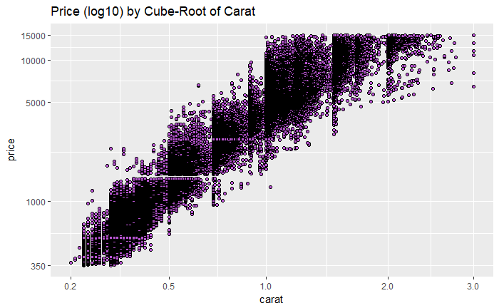

```r
ggplot(diamonds, aes(carat, price)) +
  geom_point(fill = I('#BA55D3'), color = I('black'), shape = 21) +
  scale_x_continuous(trans = cuberoot_trans(), limits = c(0.2, 3),
                     breaks = c(0.2, 0.5, 1, 2, 3)) +
  scale_y_continuous(trans = log10_trans(), limits = c(350, 15000),
                     breaks = c(350, 1000, 5000, 10000, 15000)) +
  ggtitle('Price (log10) by Cube-Root of Carat')
```

### Lesson 9.11: Overplotting Revisited

Until now we haven’t really done anything about over plotting. That’s when multiple points take on the same value. This is often due to rounding. So let’s look at this by running some code. We’re going to run the table command on both carat, and price. Then we’re going to sort that so that the highest values appear first. We’re just going to look at the top six which is the default for the head function. Of course, what’s happening here is that the first line is the price or the carat, and the second line is the count for each one of these values. We can see that these are really high numbers which is going to result in a substantial amount of overplotting. When you have this much data, you’re going to have serious overplotting, even when you’re plotting the variables against each other, and this can really obscure some of the density and the sparsity of our data. Really key points. Okay, so as we discussed in lesson four, you can deal with this by making your points smaller by jittering your points and by adding transparency. In gg plot, this is done with the alpha parameter. In the next coding exercise, you’ll do just that.

Your code should look something like this. After making these 3 adjustments, you can see that the plot gives us a better sense of how dense and how sparse our data is at key places. See?

- Hint 1: Look up the documentation for `geom_point()`.
- Hint 2: You need to adjust the parameters for `alpha`, `size`, and `position` inside `geom_point()`.
- Hint 3: To jitter the points, set `position equal` to `jitter`.

```r
head(sort(table(diamonds$carat), decreasing = T))
```

```
 0.3 0.31 1.01  0.7 0.32    1
2604 2249 2242 1981 1840 1558
```

```r
head(sort(table(diamonds$price), decreasing = T))
```

```
605 802 625 828 776 698
132 127 126 125 124 121
```

Add a layer to adjust the features of the scatterplot. Set the transparency to one half, the size to three-fourths, and jitter the points.

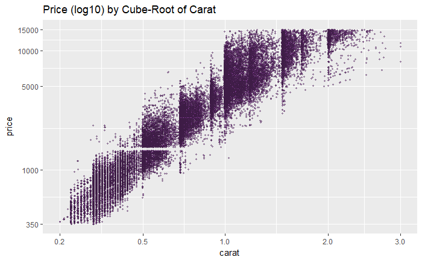

```r
ggplot(aes(carat, price), data = diamonds) +
  geom_point(fill = I('#BA55D3'), color = I('black'), shape = 21,
             alpha = 0.5, size = 0.75, position = 'jitter') +
  scale_x_continuous(trans = cuberoot_trans(), limits = c(0.2, 3),
                     breaks = c(0.2, 0.5, 1, 2, 3)) +
  scale_y_continuous(trans = log10_trans(), limits = c(350, 15000),
                     breaks = c(350, 1000, 5000, 10000, 15000)) +
  ggtitle('Price (log10) by Cube-Root of Carat')
```

### Lesson 9.12: Plot Colors for Qualitative Factors

We can see what looks like a almost linear relationship between carat weight and price after doing some transformations, but surely there are other factors that influence the price of a diamond. When I was looking around at diamonds I noticed that clarity seemed to factor into price. Of course, many consumers are looking for a diamond of a certain minimum size. So we shouldn’t expect clarity to be as strong a factor as carat weight. And I must admit that even though my grandparents were jewelers. I initially had a hard time discerning a diamond rated VVS1 from one rated SI2. Surely, most people need a jeweler’s loop to tell the difference. According to blue nile, the cut of a diamond has a much more consequential impact on that fiery quality that jewelers describe when they talk about diamonds. On clarity, the website states many of these imperfections are microscopic and do not affect the diamonds beauty in any discernible way.

### Lesson 9.13: Price vs. Carat and Clarity

Let’s see if clarity, cut, or color can explain some of the variants in price when we visualize it on our plot using color. We’ll start by examining clarity. This code visualizes price by carat. Adjust it to color the points by clarity.

We just need to add one parameter to our aesthetic wrapper in ggplot like so. Set the color parameter for equal to clarity. And when we run it, here’s what it looks like.

- ggplot2: [scale_colour_brewer](http://ggplot2.tidyverse.org/reference/scale_brewer.html)
- ggplot2: Color Brewer Palettes and Safe Colors
- ggplot2: Legends

Run the following code in RStudio to install and load the RColorBrewer package.

`install.packages('RColorBrewer', dependencies = TRUE)`

`library(RColorBrewer)`

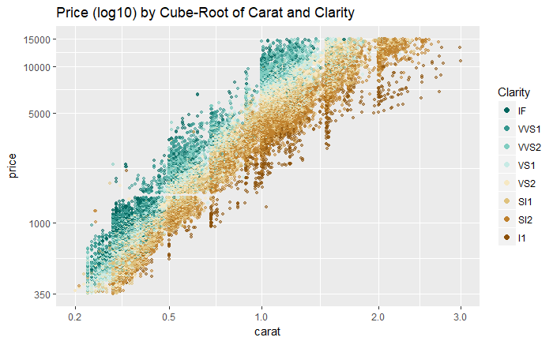

```r
ggplot(aes(x = carat, y = price, color = clarity), data = diamonds) +
  geom_point(alpha = 0.5, size = 1, position = 'jitter') +
  scale_color_brewer(type = 'div',
                     guide = guide_legend(title = 'Clarity', reverse = T,
                                          override.aes = list(alpha = 1, size = 2))) +
  scale_x_continuous(trans = cuberoot_trans(), limits = c(0.2, 3),
                     breaks = c(0.2, 0.5, 1, 2, 3)) +
  scale_y_continuous(trans = log10_trans(), limits = c(350, 15000),
                     breaks = c(350, 1000, 5000, 10000, 15000)) +
  ggtitle('Price (log10) by Cube-Root of Carat and Clarity')
```

### Lesson 9.14: Clarity and Price

Based on the plot, do you think clarity explains some of the change in price? Why? Enter your response here.

Yes, the plot visualizes the variance of carat/dollar based upon clarity.

Clarity does seem to explain an awful lot of the remaining variance in price, after adding color to our plot. Holding carat weight constant, we’re looking at one part of the plot. We see the diamonds with lower clarity are almost always cheaper than diamonds with better clarity.

### Lesson 9.15: Price vs Carat and Cut

Now let’s look at cut. Change the code such that you’re coloring the points by cut, and don’t forget to change the titles.

You might have made just one change to the code by swapping out the cut variable with the Clarity variable, but I hope you changed your titles as well. Running the code, here is the plot that we get.

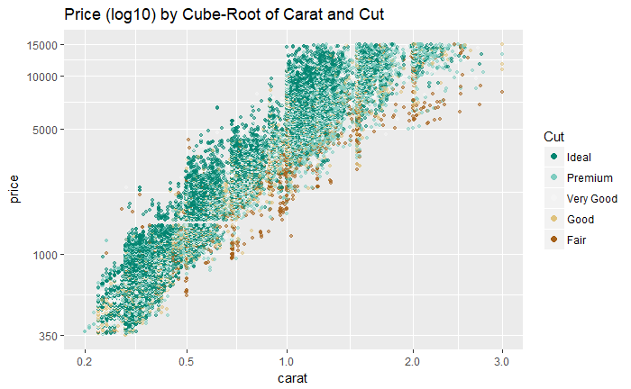

```r
ggplot(aes(x = carat, y = price, color = cut), data = diamonds) +
  geom_point(alpha = 0.5, size = 1, position = 'jitter') +
  scale_color_brewer(type = 'div',
                     guide = guide_legend(title = 'Cut', reverse = T,
                                          override.aes = list(alpha = 1, size = 2))) +
  scale_x_continuous(trans = cuberoot_trans(), limits = c(0.2, 3),
                     breaks = c(0.2, 0.5, 1, 2, 3)) +
  scale_y_continuous(trans = log10_trans(), limits = c(350, 15000),
                     breaks = c(350, 1000, 5000, 10000, 15000)) +
  ggtitle('Price (log10) by Cube-Root of Carat and Cut')
```

### Lesson 9.16: Cut and Price

Based on the plot, do you think that cut accounts for some of the variance in price, why? Enter your response here.

Despite what Blue Nile says, we don’t see much variation on cut. Most of the diamonds in the data are ideal cut anyway, so we’ve lost the color pattern that we saw before.

[Diamond Education: Cut](https://www.bluenile.com/education/diamonds/cut)

### Lesson 9.17: Price vs Carat and Color

Finally, let’s use diamond color as a color in our plot. Adjust the code below, to color the points by diamond color.

Here, I made four changes to the code. I replaced cut with color in the aesthetic wrapper. I also changed the legend title and the plot title, to use the word color. And finally, I removed the reverse parameter in the legend, so that the best color would be at the top of the list in the legend. Now that we’ve run our code, this is the output.

Did you remove reverse = T on the guide_legend? It’s a small detail that reminds us that D is the best color and J is worse for rating diamond colors.

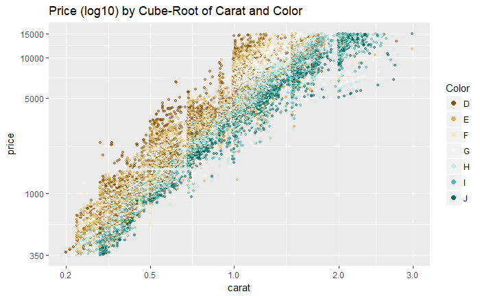

```r
ggplot(aes(x = carat, y = price, color = color), data = diamonds) +
  geom_point(alpha = 0.5, size = 1, position = 'jitter') +
  scale_color_brewer(type = 'div',
                     guide = guide_legend(title = 'Color', reverse = FALSE,
                                          override.aes = list(alpha = 1, size = 2))) +
  scale_x_continuous(trans = cuberoot_trans(), limits = c(0.2, 3),
                     breaks = c(0.2, 0.5, 1, 2, 3)) +
  scale_y_continuous(trans = log10_trans(), limits = c(350, 15000),
                     breaks = c(350, 1000, 5000, 10000, 15000)) +
  ggtitle('Price (log10) by Cube-Root of Carat and Color')
```

### Lesson 9.18: Color and Price

Based on the plot, do you think that the color of the diamond influences price? Why? Answer your answer in the box below.

Color does seem to explain some of the variance in price. Just like we saw with the clarity variable. Blue now however, states that the difference between all color grades from D to J are basically not noticeable to the naked eye. Yet, we do see the color difference in the price tag.

[Diamond Education: Color](https://www.bluenile.com/education/diamonds/color)

### Lesson 9.19: Linear Models in R

In R we can create models using the lm function. We need to supply a formula in the form of y~x. Here, y is the outcome variable and x is the explanatory variable. Which of the following formulas would we use inside the lm function?

- price~carat
- price^(1/3)~log(carat)
- log(price)~carat^3
- log(price)~carat^(1/3)

Remember we applied the log transformation to our long tailed dollar variable, and we speculated that the flawless diamond should become exponentially rarer as diamond volume increases. So we should be interested in the cube root of carat weight.

**log(price)~carat^(1/3)**

### Lesson 9.20: Building the Linear Model

Let’s buildup our linear model for price. I’m going to store the first model in a variable called m1. You probably also noticed how I used the I wrapper around each of the variables. The I stands for as is. In this case, it tells R to use the expression inside the I function to transform a variable before using it in the regression. This is instead of instructing R to interpret these symbols as part of the formula to construct the design matrix for the regression. You can read more about the syntax for linear models in the instructor notes. I can also update the previous model to add the caret variable in the regression, using the syntax. The real functional relationship is surely not as simple as the cubed root of caret, so we add a simple linear function of caret in our model predicting price. And we can continue to make more complex models by adding more variables. We add cut even though we don’t expect it to have much influence on price. Next, we add color to a fourth model and clarity to a fifth. When we run the code, we can see that we’re getting some very nice R square values. We’re accounting for almost all of the variance in price using the four Cs. If we want to know whether the price for, a diamond is reasonable, we might now use this model.

[Linear Models and Operators in R](http://data.princeton.edu/R/linearModels.html)

If you are running this code on your local computer, you may need to modify the last line to state:

`mtable(m1, m2, m3, m4, m5, sdigits = 3)`

This will ensure that the output at the end of the table shows three significant digits like shown in the video.

```r
m1 <- lm(I(log(price)) ~ I(carat^(1/3)), data = diamonds)
m2 <- update(m1, ~ . + carat)
m3 <- update(m2, ~ . + cut)
m4 <- update(m3, ~ . + color)
m5 <- update(m4, ~ . + clarity)
mtable(m1, m2, m3, m4, m5, sdigits = 3)
```

```
Calls:
m1: lm(formula = I(log(price)) ~ I(carat^(1/3)), data = diamonds)
m2: lm(formula = I(log(price)) ~ I(carat^(1/3)) + carat, data = diamonds)
m3: lm(formula = I(log(price)) ~ I(carat^(1/3)) + carat + cut, data = diamonds)
m4: lm(formula = I(log(price)) ~ I(carat^(1/3)) + carat + cut + color,
    data = diamonds)
m5: lm(formula = I(log(price)) ~ I(carat^(1/3)) + carat + cut + color +
    clarity, data = diamonds)

============================================================================================
                       m1             m2             m3             m4            m5
--------------------------------------------------------------------------------------------
  (Intercept)          2.821***       1.039***       0.874***      0.932***       0.415***
                      (0.006)        (0.019)        (0.019)       (0.017)        (0.010)
  I(carat^(1/3))       5.558***       8.568***       8.703***      8.438***       9.144***
                      (0.007)        (0.032)        (0.031)       (0.028)        (0.016)
  carat                              -1.137***      -1.163***     -0.992***      -1.093***
                                     (0.012)        (0.011)       (0.010)        (0.006)
  cut: .L                                            0.224***      0.224***       0.120***
                                                    (0.004)       (0.004)        (0.002)
  cut: .Q                                           -0.062***     -0.062***      -0.031***
                                                    (0.004)       (0.003)        (0.002)
  cut: .C                                            0.051***      0.052***       0.014***
                                                    (0.003)       (0.003)        (0.002)
  cut: ^4                                            0.018***      0.018***      -0.002
                                                    (0.003)       (0.002)        (0.001)
  color: .L                                                       -0.373***      -0.441***
                                                                  (0.003)        (0.002)
  color: .Q                                                       -0.129***      -0.093***
                                                                  (0.003)        (0.002)
  color: .C                                                        0.001         -0.013***
                                                                  (0.003)        (0.002)
  color: ^4                                                        0.029***       0.012***
                                                                  (0.003)        (0.002)
  color: ^5                                                       -0.016***      -0.003*
                                                                  (0.003)        (0.001)
  color: ^6                                                       -0.023***       0.001
                                                                  (0.002)        (0.001)
  clarity: .L                                                                     0.907***
                                                                                 (0.003)
```

[output cut: 9 more lines]

```
                                                                                 (0.002)
  clarity: ^7                                                                     0.032***
                                                                                 (0.001)
--------------------------------------------------------------------------------------------
  R-squared            0.924          0.935          0.939         0.951          0.984
  adj. R-squared       0.924          0.935          0.939         0.951          0.984
  sigma                0.280          0.259          0.250         0.224          0.129
  F               652012.063     387489.366     138654.523     87959.467     173791.084
  p                    0.000          0.000          0.000         0.000          0.000
  Log-likelihood   -7962.499      -3631.319      -1837.416      4235.240      34091.272
  Deviance          4242.831       3613.360       3380.837      2699.212        892.214
  AIC              15930.999       7270.637       3690.832     -8442.481     -68140.544
  BIC              15957.685       7306.220       3761.997     -8317.942     -67953.736
  N                53940          53940          53940         53940          53940
============================================================================================
```

### Lesson 9.21: Model Problems

Our model is the log of price equals 0.415 plus 9.144 times the cube root of carat, minus 1.093 times carat plus a series of coefficient times each factor in cut another series of coefficient times each factor in color. And another series of coefficients times each factor in clarity plus an error term. What could be some problems when using this model. What else should we think about when we’re using it. Go ahead and enter your answer here.

Let’s put our model in a larger context. Assuming that the data is not somehow corrupted and we are not egregiously violating some of the key assumptions of linear regression (for example, violating the IID assumption by having a bunch of duplicated observations in our data set), what could be some problems with this model? What else should we think about when using this model?

Take your time to answer this question, do some qualitative research about the diamond market. See the links below to get started.

[Diamond Prices over the Years](https://www.pricescope.com/diamond-prices/diamond-prices-chart)

[Global Diamond Report](http://www.bain.com/publications/articles/global-diamond-report-2013.aspx)

[Falling Supply and Rising Demand: Couples in Shanghai take to the Ring](http://diamonds.blogs.com/diamonds_update/diamond-prices/)

If you’d like to learn more about linear models and how to interpret regression coefficients, please refer to the following articles.

[Interpreting Regression Coefficients in R](https://www.r-bloggers.com/interpreting-regression-coefficient-in-r/?utm_source=feedburner&utm_medium=email&utm_campaign=Feed%3A+RBloggers+%28R+bloggers%29) on R Bloggers

[Interpreting Regression Coefficients](http://www.theanalysisfactor.com/interpreting-regression-coefficients/) on the Analysis Factor blog

[Fitting and Interpreting Linear Models](http://blog.yhat.com/posts/r-lm-summary.html) by yhat

[Another Explanation of Factor Coefficients in Linear Models](https://stats.stackexchange.com/questions/24242/how-to-apply-coefficient-term-for-factors-and-interactive-terms-in-a-linear-equa/24256#24256) on Stats StackExchange

**Our Model Is…**

ln(price) = 0.415 + 9.144 * carat^(1/3) - 1.093 * carat + (…* cut + …* color + …* clarity) + epsilon

### Lesson 9.22: A Bigger, Better Data Set

Thankfully, I was able to put together a Python script to get the current diamond price data, similar to the original diamonds data set, from diamondse.info without too much trouble. This data set is about ten times the size of the 2008 diamonds data set, and features diamonds from all over the world certified by an array of authorities, besides just the General Logical Institute Of America, or the GIA. You can read in this data set as follows, but make sure you’ve installed the R curl and bit tops libraries before you do. This might take a while as a data set contains over about 500,000 cases. The code used to obtain the data is available at this link. Let’s fit the model again to the big data set. We’ll only use GIA certified diamonds in this log. I look only at diamonds under $10,000 because these are the type of diamonds sold at most retailers, and hence, the kind we care most about. By trimming the most expensive diamonds from the data set, our model will also be less likely to be thrown off by outliers, and the higher variants at the high-end of price and carat.

What we will do first is make a variable called logged price, the log of diamond price. And then we will build our model similarly to the way that we did for the small diamond status set. Notice that we’re setting price by diamonds who’s price is less than $10,000 and who’s certificate is G.I.A.. Thankfully our models look quite a bit like they did for the smaller diamond status set. Although our r squared values are just a touch weaker.

If the code shown in the video does not work, the dataset is available for download here: https://github.com/SolomonMg/diamonds-data/blob/master/BigDiamonds.Rda. Click on the BigDiamonds.Rda link, then click on the “Raw” button to start the download. Once downloaded, the data can be loaded using the command ‘load(“BigDiamonds.rda”)’, assuming that the file is in your working directory.

You can learn how to scrape data from the web just like Solmon did! [Take Data Wrangling with MongoDB: Data Manipulation and Retrieval](https://www.udacity.com/course/data-wrangling-with-mongodb--ud032) with us.

```r
load('BigDiamonds.Rda')
```

```r
diamondsbig$logprice = log(diamondsbig$price)
```

```r
m1 <- lm(logprice ~ I(carat^(1/3)),
         data = diamondsbig[diamondsbig$price < 10000 &
                              diamondsbig$cert == 'GIA',])
m2 <- update(m1, ~ . + carat)
m3 <- update(m2, ~ . + cut)
m4 <- update(m3, ~ . + color)
m5 <- update(m4, ~ . + clarity)
mtable(m1, m2, m3, m4, m5)
```

```
Calls:
m1: lm(formula = logprice ~ I(carat^(1/3)), data = diamondsbig[diamondsbig$price <
    10000 & diamondsbig$cert == "GIA", ])
m2: lm(formula = logprice ~ I(carat^(1/3)) + carat, data = diamondsbig[diamondsbig$price <
    10000 & diamondsbig$cert == "GIA", ])
m3: lm(formula = logprice ~ I(carat^(1/3)) + carat + cut, data = diamondsbig[diamondsbig$price <
    10000 & diamondsbig$cert == "GIA", ])
m4: lm(formula = logprice ~ I(carat^(1/3)) + carat + cut + color,
    data = diamondsbig[diamondsbig$price < 10000 & diamondsbig$cert ==
        "GIA", ])
m5: lm(formula = logprice ~ I(carat^(1/3)) + carat + cut + color +
    clarity, data = diamondsbig[diamondsbig$price < 10000 & diamondsbig$cert ==
    "GIA", ])

================================================================================================
                        m1              m2             m3             m4              m5
------------------------------------------------------------------------------------------------
  (Intercept)           2.671***        1.333***       0.949***       0.529***       -0.464***
                       (0.003)         (0.012)        (0.012)        (0.010)         (0.009)
  I(carat^(1/3))        5.839***        8.243***       8.633***       8.110***        8.320***
                       (0.004)         (0.022)        (0.021)        (0.017)         (0.012)
  carat                                -1.061***      -1.223***      -0.782***       -0.763***
                                       (0.009)        (0.009)        (0.007)         (0.005)
  cut: V.Good                                          0.120***       0.090***        0.071***
                                                      (0.002)        (0.001)         (0.001)
  cut: Ideal                                           0.211***       0.181***        0.131***
                                                      (0.002)        (0.001)         (0.001)
  color: K/L                                                          0.123***        0.117***
                                                                     (0.004)         (0.003)
  color: J/L                                                          0.312***        0.318***
                                                                     (0.003)         (0.002)
  color: I/L                                                          0.451***        0.469***
                                                                     (0.003)         (0.002)
  color: H/L                                                          0.569***        0.602***
                                                                     (0.003)         (0.002)
  color: G/L                                                          0.633***        0.665***
                                                                     (0.003)         (0.002)
  color: F/L                                                          0.687***        0.723***
                                                                     (0.003)         (0.002)
  color: E/L                                                          0.729***        0.756***
```

[output cut: 16 more lines]

```
                                                                                     (0.006)
  clarity: IF                                                                         1.052***
                                                                                     (0.006)
------------------------------------------------------------------------------------------------
  R-squared             0.888           0.892          0.899          0.937           0.969
  adj. R-squared        0.888           0.892          0.899          0.937           0.969
  sigma                 0.289           0.284          0.275          0.216           0.154
  F               2700903.714     1406538.330     754405.425     423311.488      521161.443
  p                     0.000           0.000          0.000          0.000           0.000
  Log-likelihood   -60137.791      -53996.269     -43339.818      37830.414      154124.270
  Deviance          28298.689       27291.534      25628.285      15874.910        7992.720
  AIC              120281.582      108000.539      86691.636     -75632.827     -308204.540
  BIC              120313.783      108043.473      86756.037     -75482.557     -307968.400
  N                338946          338946         338946         338946          338946
================================================================================================
```

### Lesson 9.23: Predictions

After all this work, lets use our model to make a prediction. We need to exponentiate the result of our model. Since we took the log of price. Let’s take a look at an example from Blue Nile. We’ll use the full model m5, to predict the value of the diamond. Try to understand what this code does. If you see something you don’t understand, look it up in the documentation, then answer the question. Evaluate how well the model predicts the Blue Nile diamond price. Think about the fitted point estimate. As well as, the lower and upper bound of the 95% confidence interval.

```r
thisDiamond = data.frame(carat = 1.00, cut = 'V.Good',
                         color = 'I', clarity = 'VS1')
modelEstimate = predict(m5, newdata = thisDiamond,
                        interval = 'prediction', level = 0.95)
modelEstimate
```

```
       fit      lwr      upr
1 8.525248 8.224255 8.826241
```

```r
exp(modelEstimate)
```

```
       fit     lwr      upr
1 5040.436 3730.34 6810.638
```

The results yield an expected value for price given the characteristics of our diamond, and the upper and lower bounds of a 95% confidence level. Note, because this is a linear model, predict is just multiplying each model coefficient by each value in our data. It turns out that this diamond is a touch pricier than the expected value under the full model, though it is by no means outside of the 95% confidence interval. Blue now has by most accounts a better reputation than diamond SE.info however. And reputation is worth a lot in a business that relies on easy to forge certificates in which the non-expert can be easily fooled. So, while this model might give you a sense of whether your diamond is a ripoff against diamondSE.info diamonds, it’s not clear that diamondSE.info should be regarded as the universal source of truth over whether the price of a diamond is reasonable. Nonetheless, to have the expected price and diamondassay.info with a 95% interval, is a lot more information than we had about the price we should be willing to pay for a diamond before we started this exercise.

[Confidence Intervals](https://en.wikipedia.org/wiki/Confidence_interval)

The prediction interval here may be slightly conservative, as the model errors are heteroskedastic over carat (and hence price) even after our log and cube-root transformations.

See the output of the following code.

```r
dat = data.frame(m4$model, m4$residuals)
with(dat, sd(m4.residuals))
```

```
[1] 0.2164168
```

```r
with(subset(dat, carat > .9 & carat < 1.1), sd(m4.residuals))
```

```
[1] 0.2178147
```

```r
dat$resid <- as.numeric(dat$m4.residuals)
```

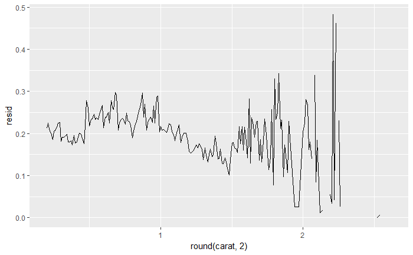

```r
ggplot(aes(y = resid, x = round(carat, 2)), data = dat) +
  geom_line(stat = "summary", fun.y = sd)
```

How could we do better? If we care most about diamonds with carat weights between 0.50 and 1.50, we might restrict the data we use to fit our model to diamonds that are that size - we have enough data.

### Lesson 9.24: Final Thoughts

An important point. Even though we can predict the price of a diamond based on a function for c’s. One thing you should not conclude with this exercise is that where you buy your diamond is irrelevant. You almost surely pay more for the same diamond at Tiffany’s compared to Costco. Regardless you can use a model like this to get a sense of whether you were overpaying. One last thing, data and models are never infallible and you can still get taken even equipped with this kind of analysis. There’s no substitute for establishing a personal connection and lasting business relationship with a jeweler you can trust.

[Tiffany vs. Costco: Which Diamond Ring is Better](https://www.bloomberg.com/news/articles/2013-05-06/tiffany-vs-dot-costco-which-diamond-ring-is-better)

[But Costco Sells Pricy Diamonds Too](https://www.costco.com/engagement.html)

### Lesson 9.25: Congratulations and Next Steps

Learn how to [analyze your Facebook social network and more](http://blog.revolutionanalytics.com/2013/11/how-to-analyze-you-facebook-friends-network-with-r.html)!

Thank you for joining us! Please fill out this brief survey about the course to let us know how we’re doing and what you’d like to see in the future!